# BE3_partie1

# Exercice 1

## Question 1

```r
library(DiceEval)
library(car)
library(MASS)

bitume_train = read.table("bitume.train.txt", header = T)
bitume_test = read.table("bitume.test.txt", header = T)

head(bitume_train)
```

[output not shown]

[output cut: 3583 more lines]

## Question 2

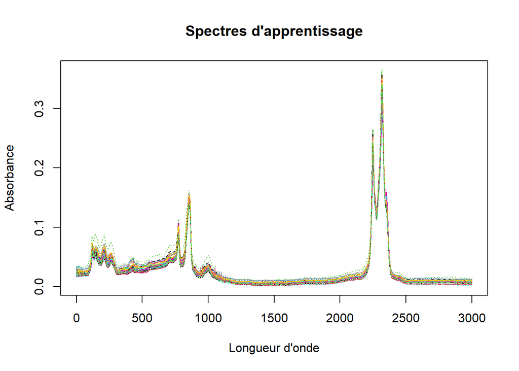

```r
matplot(t(bitume_train[, -1]), type='l', col=1:35, xlab='Longueur d\'onde', ylab='Absorbance', main='Spectres d\'apprentissage')
```

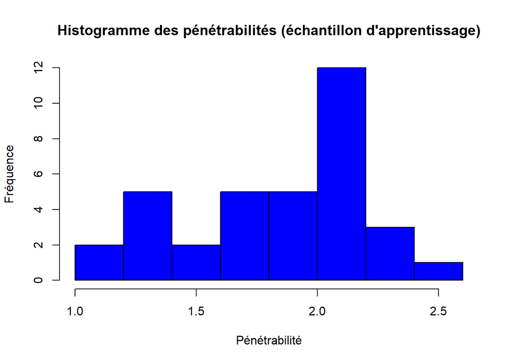

```r
hist(bitume_train$PENE, main='Histogramme des pénétrabilités (échantillon d\'apprentissage)', xlab='Pénétrabilité', ylab='Fréquence', col='blue')
```

## Question 3

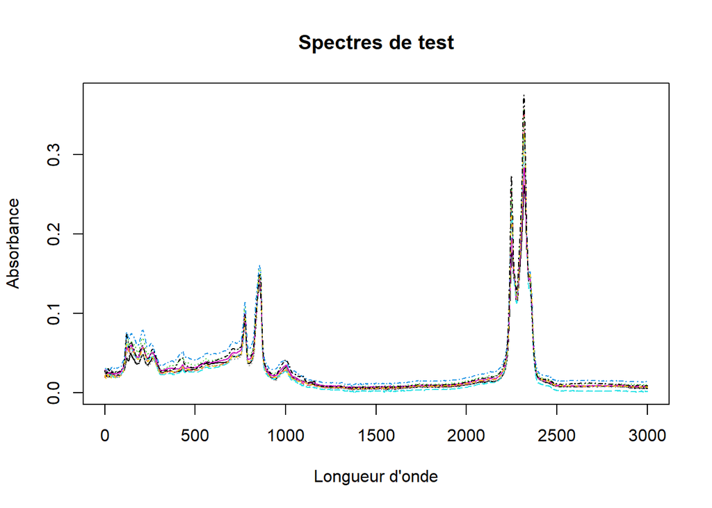

```r
 matplot(t(bitume_test[, -1]), type='l', col=1:9, xlab='Longueur d\'onde', ylab='Absorbance', main='Spectres de test')
```

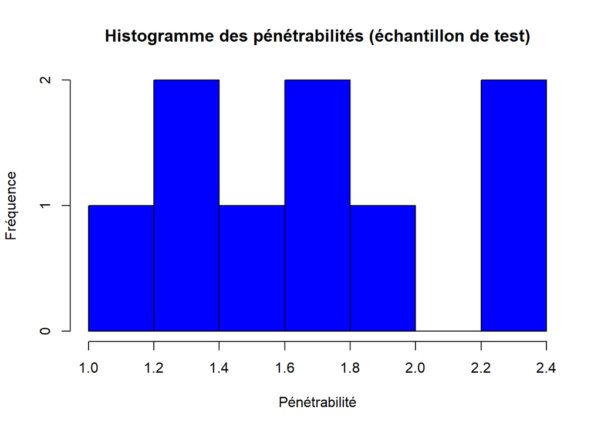

```r
hist(bitume_test$PENE, main='Histogramme des pénétrabilités (échantillon de test)', xlab='Pénétrabilité', ylab='Fréquence', col='blue')
```

## Question BONUS

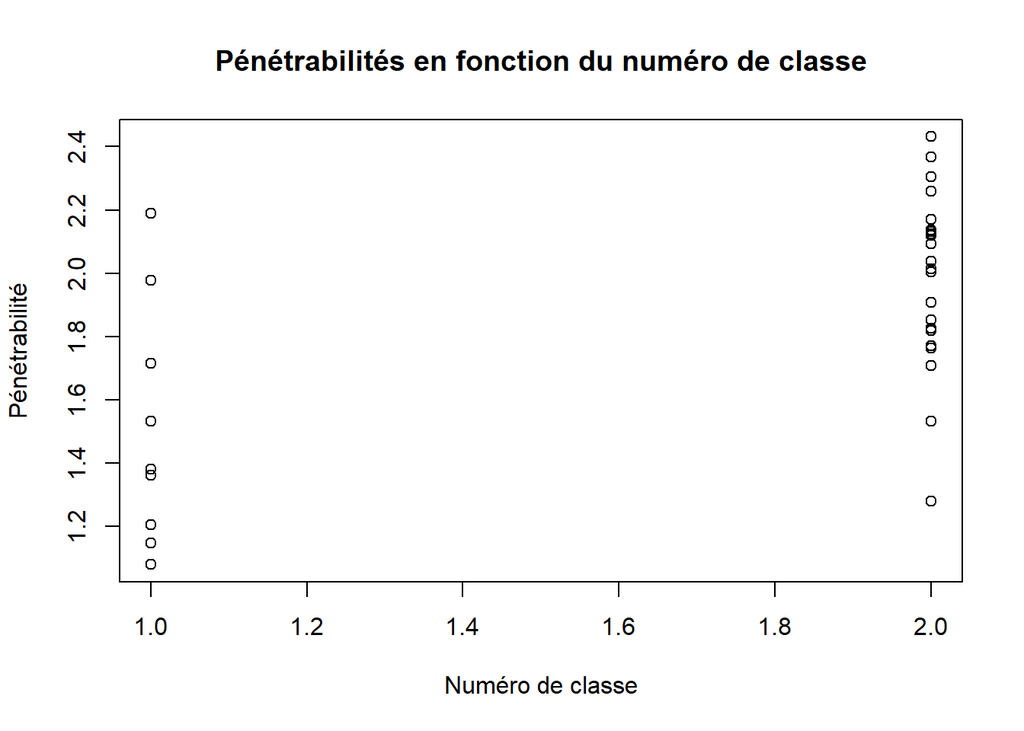

```r
k <- 2  # Nombre de clusters
cluster <- kmeans(bitume_train[, -1], centers = k)

plot(cluster$cluster, bitume_train$PENE,
     xlab = "Numéro de classe", ylab = "Pénétrabilité",
     main = "Pénétrabilités en fonction du numéro de classe")
```

Il semble y avoir un lien entre la pénétrabilité et les clusters, avec une classe admettant une pénétrabilité autour de 2 et l’autre autour de 1.4, ce qui respecte la distribution visible sur l’histogramme des pénétrabilités.

## Question 4

```r
library(pls)
```

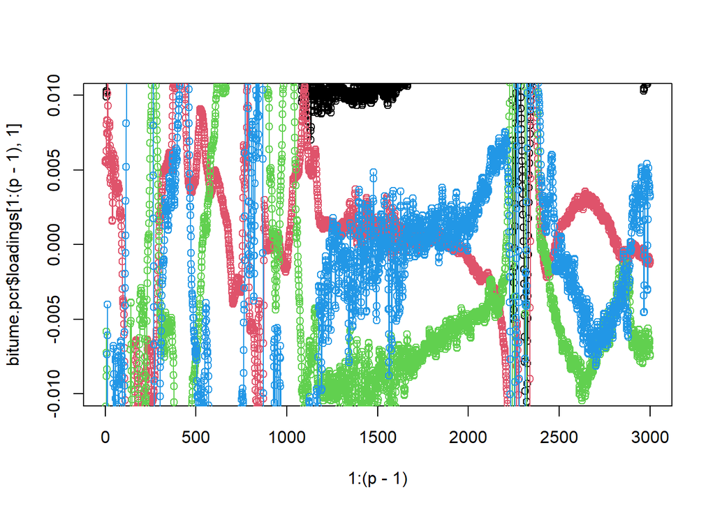

```r
#PCR
bitume.pcr <- pcr(PENE ~ ., data = bitume_train, ncomp=30)

#tracer des premières fonctions propres
p = ncol(bitume_train)
par(mfrow =c(1,1))
plot(1:(p-1),bitume.pcr$loadings[1:(p-1),1],type ="l",col = 1,ylim =c(-0.01,0.01))
points(1:(p-1),bitume.pcr$loadings[1:(p-1),1],col = 1)
for (i in 2:4)
{
  points(1:(p-1),bitume.pcr$loadings[1:(p-1),i],col = i)
  lines(1:(p-1),bitume.pcr$loadings[1:(p-1),i],col = i)
}
```

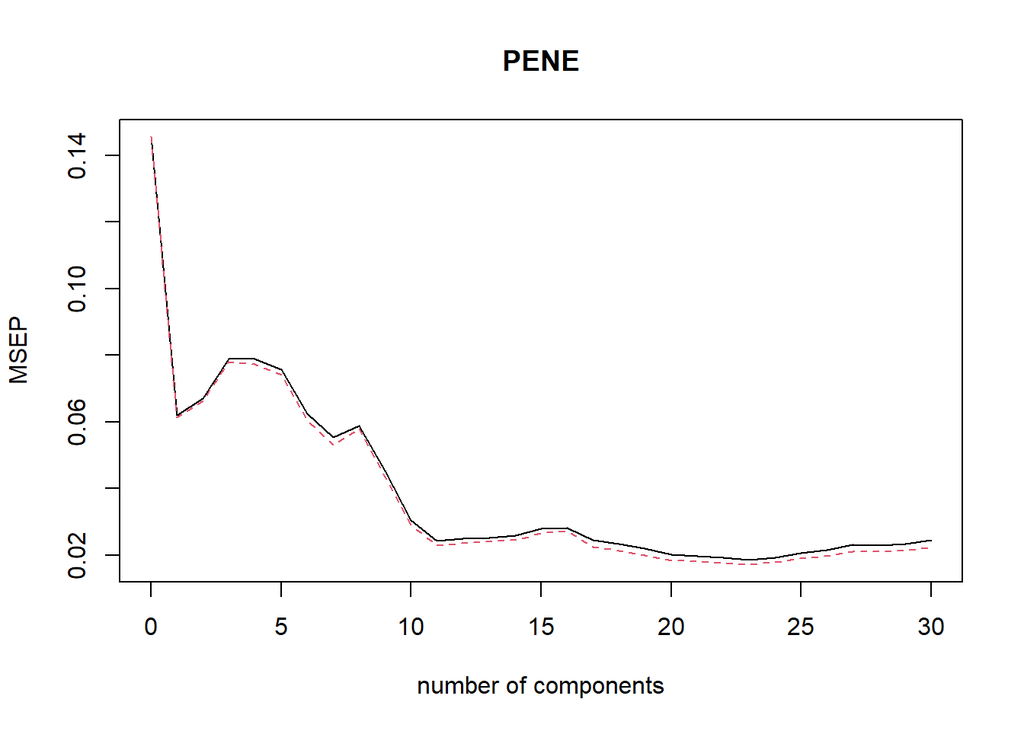

```r
bitume.cv <- crossval(bitume.pcr, segments=10)
plot(MSEP(bitume.cv))
```

On fixera donc ncomp à 10 pour le modèle PCR.

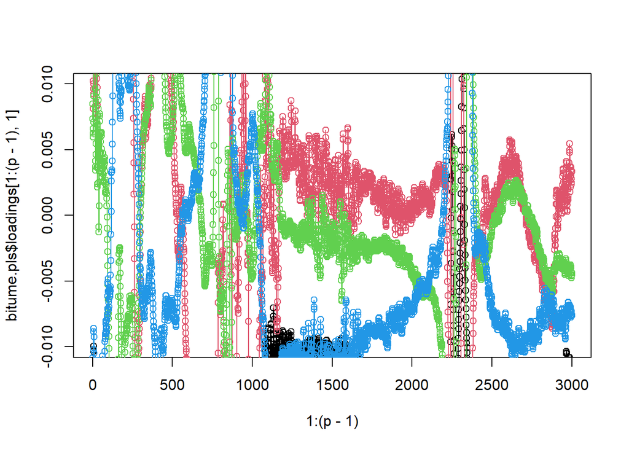

```r
#PLS
bitume.pls <- plsr(PENE ~ ., data = bitume_train, ncomp=30)

par(mfrow =c(1,1))
plot(1:(p-1),bitume.pls$loadings[1:(p-1),1],type ="l",col = 1,ylim =c(-0.01,0.01))
points(1:(p-1),bitume.pls$loadings[1:(p-1),1],col = 1)
for (i in 2:4)
{
  points(1:(p-1),bitume.pls$loadings[1:(p-1),i],col = i)
  lines(1:(p-1),bitume.pls$loadings[1:(p-1),i],col = i)
}
```

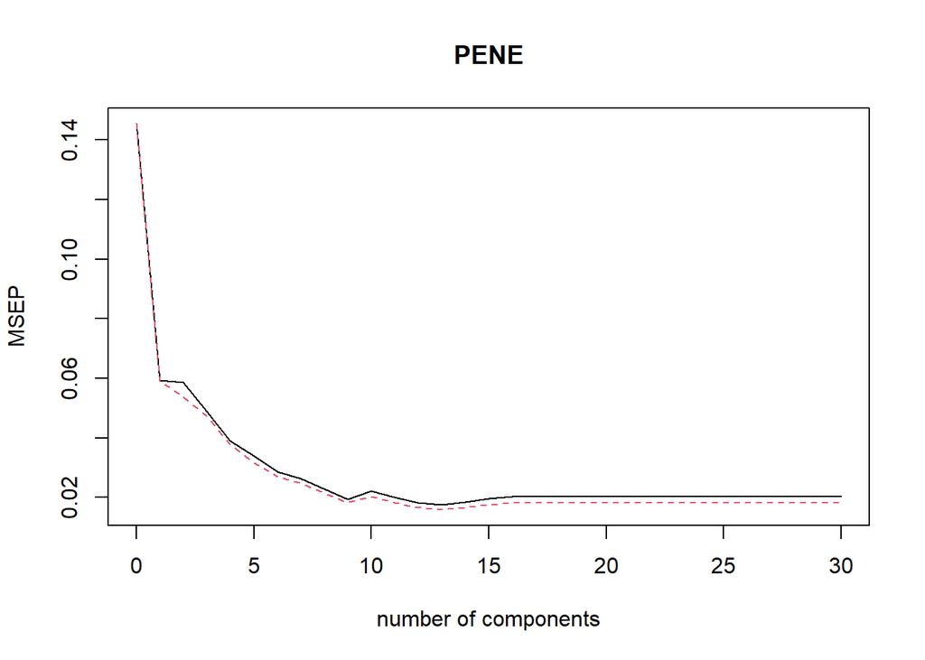

```r
 bitume.cv2 <- crossval(bitume.pls, segments=10)
 plot(MSEP(bitume.cv2))
```

On fixera donc ncomp à 8 pour le modèle PLS.

```r
#--------------------------------------------------------------
# lasso
#--------------------------------------------------------------
library(lars)
y = as.matrix(bitume_train[,1])
x = as.matrix(bitume_train[,-1])

mod_lasso =lars(x, y, type = "lasso")
```

```
## There are more than 500 variables and n<m;
## You may wish to restart and set use.Gram=FALSE
```

```r
Y_PCR = predict(bitume.pcr, newdata = bitume_test, ncomp = 10, type = "response")
RMSE_pcr = RMSE(bitume_test[,1], Y_PCR)

Y_PLS = predict(bitume.pls, newdata = bitume_test, ncomp = 8, type = "response")
RMSE_pls = RMSE(bitume_test[,1], Y_PLS)

newx = as.matrix(bitume_test[,-1])
value = 0.5

fits <- predict.lars(mod_lasso, newx, s=value, mode="fraction", type="fit")
RMSE_lasso = RMSE(bitume_test[,1], unlist(fits)[-c(1:3)])

c(RMSE_pcr,RMSE_pls,RMSE_lasso)
```

```
## [1] 0.3273497 0.1986621 0.2205037
```

La méthode PLS donne les meilleurs résultats sur la base de données de test.

## Question 5

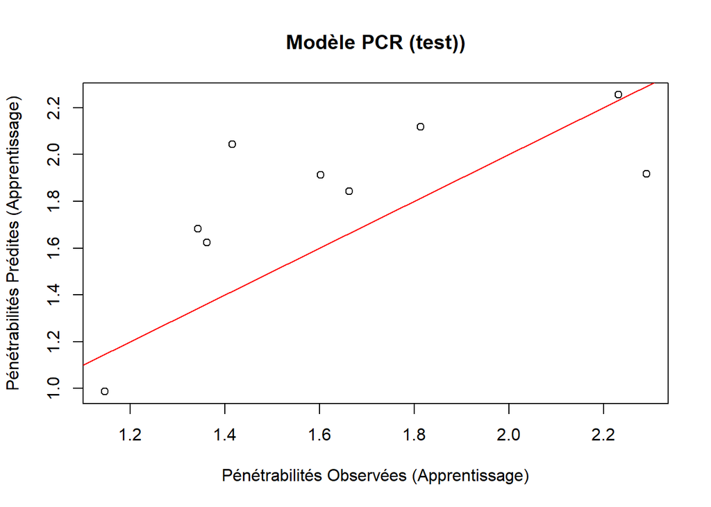

```r
plot(bitume_test[,1], Y_PCR,
     xlab = "Pénétrabilités Observées (Apprentissage)",
     ylab = "Pénétrabilités Prédites (Apprentissage)",
     main = "Modèle PCR (test))")
abline(0, 1, col = "red") # Ajoute une ligne de référence pour montrer la relation parfaite
```

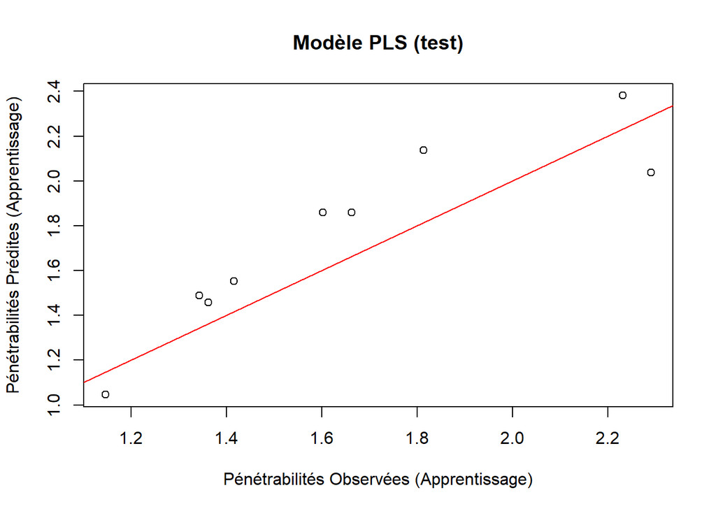

```r
plot(bitume_test[,1], Y_PLS,
     xlab = "Pénétrabilités Observées (Apprentissage)",
     ylab = "Pénétrabilités Prédites (Apprentissage)",
     main = "Modèle PLS (test)")
abline(0, 1, col = "red")
```

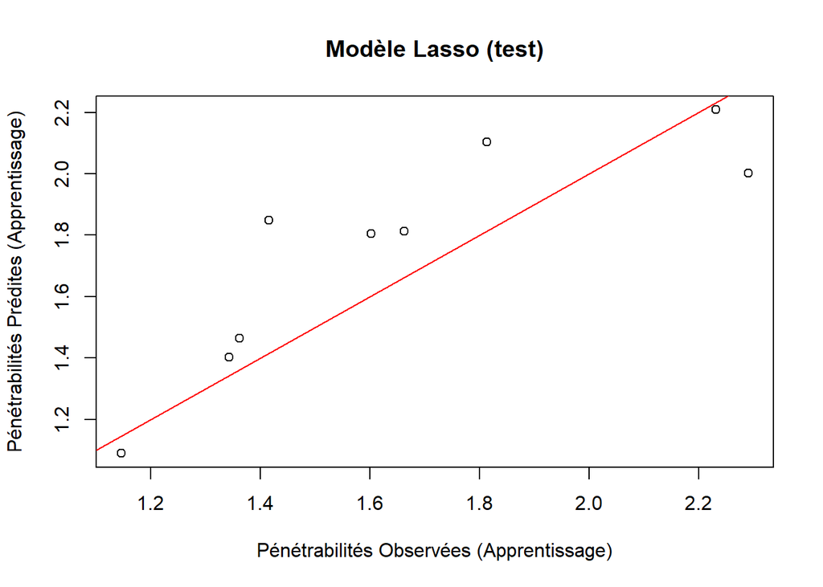

```r
plot(bitume_test[,1],  unlist(fits)[-c(1:3)],
     xlab = "Pénétrabilités Observées (Apprentissage)",
     ylab = "Pénétrabilités Prédites (Apprentissage)",
     main = "Modèle Lasso (test)")
abline(0, 1, col = "red")
```

# Exercice 2

## Question 1

```r
Carseats <- read.table("Carseats.txt", sep="",header=T)

proportion_apprentissage <- 0.7
set.seed(123)
indices_apprentissage <- sample(1:nrow(Carseats), size = round(proportion_apprentissage * nrow(Carseats)))

ensemble_apprentissage <- Carseats[indices_apprentissage, ]
ensemble_test <- Carseats[-indices_apprentissage, ]
```

## Question 2

## Modèle CART

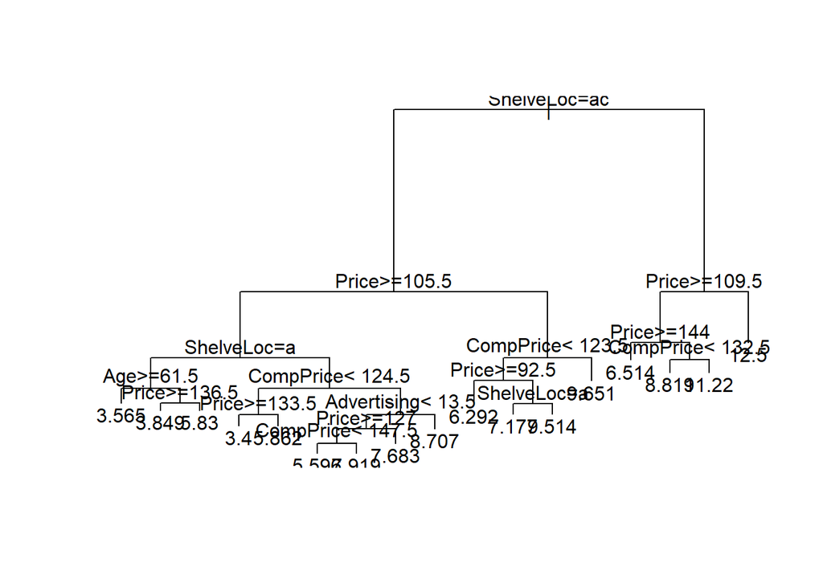

```r
#install.packages("rpart")
library(rpart)

modele_cart <- rpart(Sales ~ ., data = ensemble_apprentissage)
plot(modele_cart)
text(modele_cart)
```

Avantages : - Facile à comprendre et à interpréter. - Ne nécessite pas beaucoup de prétraitement des données. - Peut capturer des relations non linéaires. Inconvénients : - Tendance à l’overfitting (surapprentissage). - Sensible aux données d’entrée (pettes variations peuvent conduire à des arbres différents).

## Modèle Random Forest

```r
#install.packages("randomForest")
library(randomForest)
modele_rf <- randomForest(Sales ~ ., data = ensemble_apprentissage)
```

Avantages :

- Robuste aux valeurs aberrantes et aux overfitting.
- Gère naturellement les variables continues et catégoriques.
- Peut fournir une estimation de l’importance des variables.

Inconvénients :

- Moins interprétable que les arbres de décision individuels.
- Le temps de calcul peut être élevé pour de grands ensembles de données.

## Modèle Bagging

```r
#install.packages("ipred")
library(ipred)
modele_bagging <- bagging(Sales ~ ., data = ensemble_apprentissage)
```

Avantages :

- Réduit la variance en moyennant plusieurs modèles.
- Peut améliorer les performances des modèles instables.

Inconvénients :

- Ne peut pas améliorer les performances si le modèle de base est déjà très performant.
- Les modèles individuels doivent être diversifiés pour que le bagging soit efficace.

## Modèle Boosting

```r
#install.packages("gbm")
library(gbm)
ensemble_apprentissage$ShelveLoc <- as.factor(ensemble_apprentissage$ShelveLoc)
ensemble_apprentissage$Urban <- as.factor(ensemble_apprentissage$Urban)
ensemble_apprentissage$US <- as.factor(ensemble_apprentissage$US)
modele_boosting <- gbm(Sales ~ ., data = ensemble_apprentissage, distribution = "gaussian", n.trees = 500, interaction.depth = 4)
```

Avantages :

- Peut améliorer les performances des modèles faibles.
- Gère bien les données bruyantes.

Inconvénients :

- Sensible aux valeurs aberrantes.
- Plus lent à entraîner que les modèles CART.

## Illustration sur les données Carseats

```r
# Prédictions sur l'ensemble de test pour chaque modèle
predictions_cart <- predict(modele_cart, newdata = ensemble_test)
predictions_rf <- predict(modele_rf, newdata = ensemble_test)
predictions_bagging <- predict(modele_bagging, newdata = ensemble_test)
predictions_boosting <- predict(modele_boosting, newdata = ensemble_test)
```

```
## Using 500 trees...
```

```r
# Calcul des métriques d'évaluation (RMSE) pour chaque modèle
rmse_cart <- sqrt(mean((predictions_cart - ensemble_test$Sales)^2))
rmse_rf <- sqrt(mean((predictions_rf - ensemble_test$Sales)^2))
rmse_bagging <- sqrt(mean((predictions_bagging - ensemble_test$Sales)^2))
rmse_boosting <- sqrt(mean((predictions_boosting - ensemble_test$Sales)^2))

# Afficher les résultats
cat("RMSE pour CART:", rmse_cart, "\n")
```

```
## RMSE pour CART: 1.945358
```

```r
cat("RMSE pour RF:", rmse_rf, "\n")
```

```
## RMSE pour RF: 1.70894
```

```r
cat("RMSE pour Bagging:", rmse_bagging, "\n")
```

```
## RMSE pour Bagging: 1.64357
```

```r
cat("RMSE pour Boosting:", rmse_boosting, "\n")
```

```
## RMSE pour Boosting: 2.199532
```

## Question 3

Le modèle qui semble avoir la meilleure performance sur l’ensemble test (RMSE le plus faible) est donc le Bagging.

## Question 4

Voici le code R pour une sélection backward basée sur le critère AIC :

```r
# Construction du modèle
modele_initial <- lm(Sales ~ ., data = ensemble_apprentissage)

# Construction du nouveau modèle
modele_backward <- step(modele_initial, direction = "backward")
```

```
## Start:  AIC=17.15
## Sales ~ CompPrice + Income + Advertising + Population + Price +
##     ShelveLoc + Age + Education + Urban + US
##
##               Df Sum of Sq     RSS    AIC
## - Population   1      0.07  273.30  15.22
## - Urban        1      0.15  273.38  15.30
## <none>                      273.23  17.15
## - Education    1      2.04  275.28  17.24
## - US           1      4.15  277.38  19.37
## - Income       1     38.09  311.32  51.69
## - Advertising  1    103.76  377.00 105.29
## - Age          1    145.91  419.14 134.96
## - CompPrice    1    411.13  684.37 272.24
## - ShelveLoc    2    754.56 1027.79 384.11
## - Price        1    925.76 1198.99 429.25
##
## Step:  AIC=15.22
## Sales ~ CompPrice + Income + Advertising + Price + ShelveLoc +
##     Age + Education + Urban + US
##
##               Df Sum of Sq     RSS    AIC
## - Urban        1      0.14  273.44  13.37
## <none>                      273.30  15.22
## - Education    1      2.14  275.45  15.41
## - US           1      4.50  277.80  17.79
## - Income       1     38.07  311.38  49.74
## - Advertising  1    117.85  391.15 113.61
## - Age          1    146.29  419.59 133.26
## - CompPrice    1    416.60  689.91 272.50
## - ShelveLoc    2    755.81 1029.12 382.47
## - Price        1    929.47 1202.78 428.13
##
## Step:  AIC=13.37
## Sales ~ CompPrice + Income + Advertising + Price + ShelveLoc +
##     Age + Education + US
##
##               Df Sum of Sq     RSS    AIC
## <none>                      273.44  13.37
## - Education    1      2.14  275.58  13.55
## - US           1      4.44  277.89  15.88
## - Income       1     38.34  311.78  48.10
## - Advertising  1    117.84  391.28 111.70
## - Age          1    146.20  419.64 131.29
## - CompPrice    1    421.36  694.81 272.48
## - ShelveLoc    2    756.81 1030.25 380.78
## - Price        1    932.10 1205.55 426.77
```

```r
# Affichage du modèle final
summary(modele_backward)
```

```
##
## Call:
## lm(formula = Sales ~ CompPrice + Income + Advertising + Price +
##     ShelveLoc + Age + Education + US, data = ensemble_apprentissage)
##
## Residuals:
##     Min      1Q  Median      3Q     Max
## -2.7190 -0.7304  0.0509  0.6599  2.5947
##
## Coefficients:
##                  Estimate Std. Error t value Pr(>|t|)
## (Intercept)      5.541966   0.684768   8.093 1.99e-14 ***
## CompPrice        0.097907   0.004800  20.397  < 2e-16 ***
## Income           0.013524   0.002198   6.153 2.74e-09 ***
## Advertising      0.136290   0.012635  10.787  < 2e-16 ***
## Price           -0.096656   0.003186 -30.338  < 2e-16 ***
## ShelveLocGood    4.935670   0.181074  27.258  < 2e-16 ***
## ShelveLocMedium  2.029499   0.148181  13.696  < 2e-16 ***
## Age             -0.045995   0.003828 -12.015  < 2e-16 ***
## Education       -0.033136   0.022790  -1.454   0.1471
## USYes           -0.367007   0.175241  -2.094   0.0372 *
## ---
## Signif. codes:  0 '***' 0.001 '**' 0.01 '*' 0.05 '.' 0.1 ' ' 1
##
## Residual standard error: 1.006 on 270 degrees of freedom
## Multiple R-squared:  0.8772, Adjusted R-squared:  0.8731
## F-statistic: 214.4 on 9 and 270 DF,  p-value: < 2.2e-16
```